# Coliforms in The Panama Canal Watershed

#### Hypothesis #3: Coliform count will differ between sample sites due to varying sample site environments. If variables such as pH differ significantly between locations, coliform growth will be directly affected. Studies have demonstrated that *E. coli* bacteria optimally survive between 20°C and 40°C (Kumar & Libchaber, 2013). For pH, researchers analyzing samples from Osijek-Baranja, Croatia observed a greater abundance of coliforms under a slightly acidic to neutral water pH (Habuda-Stanić *et al*, 2013).

For this next set of data, I’ll be looking into the relationship between sample site and total coliform count. I predict that coliform MPN will be dependent on sample site, as pH between sites differs significantly. From my sources, I know that studies have demonstrated optimal coliform growth under a certain pH range.

Since coliform count is a new variable that I’m working with, I will make a histogram to check how data is distributed.

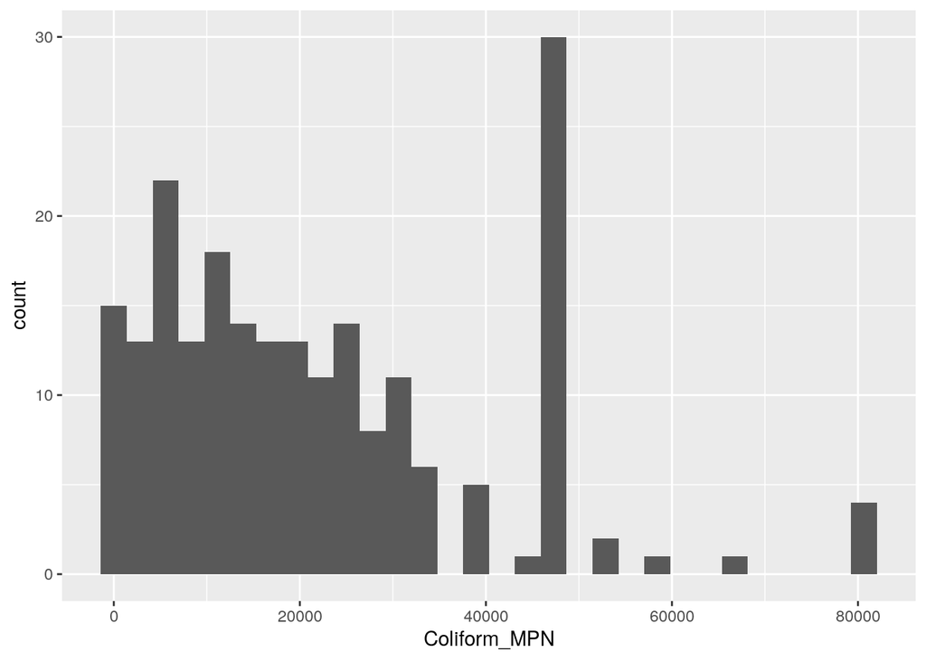

There appear to be some points (such as that near the 80,000 MPN mark) that are quite distant from the majority of others. These could certainly impact tests, given the large range of values.

As this data contains a categorical variable, a boxplot should suffice to view correlations between variables. For my final plot, I will take into account results from a Tukey test, as I did in my last test which contained the same categorical variable.

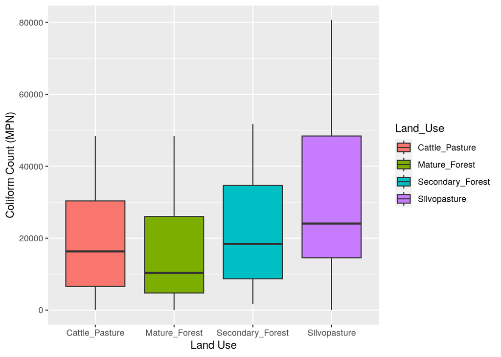

Now, to set up a linear model for autoplot and one-way Anova testing.

```r
Land_Coliform <- lm(Coliform_MPN ~ Land_Use, data=Bacteria_Data3)
```

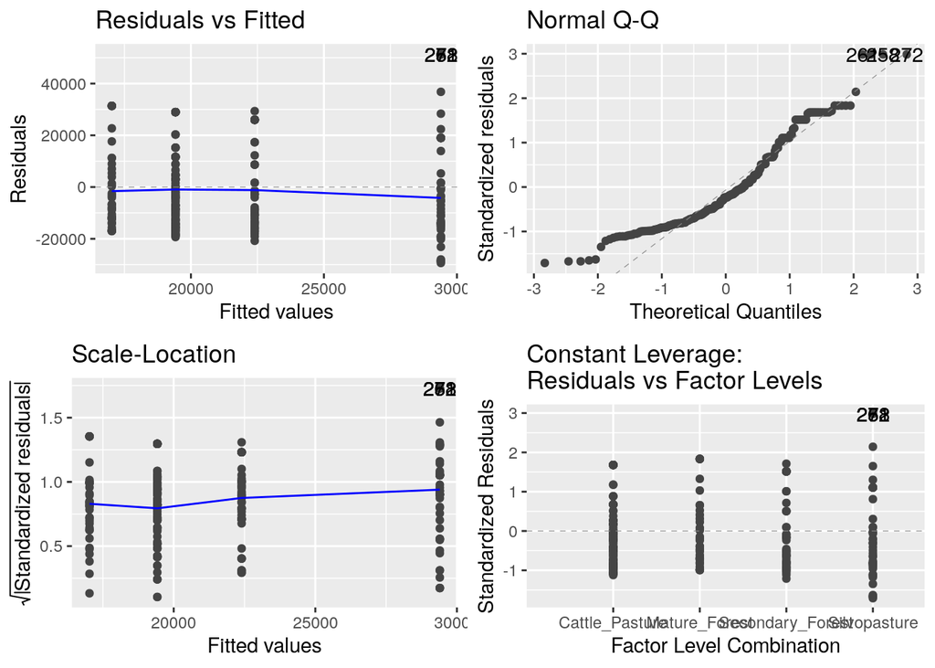

Theoretical quartile points deviate towards the beginning, like pH and dissolved O2. As I had done with other such variables, I will continue with a standard linear model for now.

```r
anova(Land_Coliform)
```

```
## Analysis of Variance Table
##
## Response: Coliform_MPN
##            Df     Sum Sq    Mean Sq F value   Pr(>F)
## Land_Use    3 4.2576e+09 1419196073  4.7155 0.003305 **
## Residuals 211 6.3503e+10  300963849
## ---
## Signif. codes:  0 '***' 0.001 '**' 0.01 '*' 0.05 '.' 0.1 ' ' 1
```

```
##              Df    Sum Sq   Mean Sq F value Pr(>F)
## Land_Use      3 4.258e+09 1.419e+09   4.716 0.0033 **
## Residuals   211 6.350e+10 3.010e+08
## ---
## Signif. codes:  0 '***' 0.001 '**' 0.01 '*' 0.05 '.' 0.1 ' ' 1
```

```
##                  Letters monospacedLetters LetterMatrix.a LetterMatrix.b
## Silvopasture           a                a            TRUE          FALSE
## Secondary_Forest      ab                ab           TRUE           TRUE
## Cattle_Pasture         b                 b          FALSE           TRUE
## Mature_Forest          b                 b          FALSE           TRUE
```

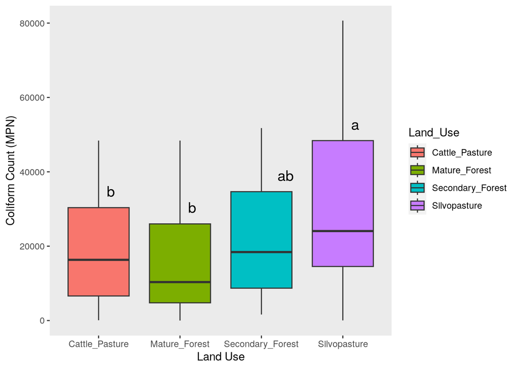

From this plot, we can observe several correlations between sites. First, Cattle_Pasture, Mature_Forest, and Secondary_Forest do not significantly differ from one another in terms of coliform count. Additionally, Secondary_Forest and Silvopasture do not significantly differ either. However, this chart shows that coliform counts from Cattle_Pasture and Mature_Forest differ significantly from those of Silvopasture

### Hypothesis #4: My final hypothesis is that different variables will have varying degrees of significance in predicting coliform count. To test this, I will perform multiple regression analysis to visualize how temperature, pH, water conductivity, dissolved O2, and sample site affect coliform count.

Finally, I’ll be analyzing the relationship between coliform count and sample site, pH, temperature, dissolved O2, and conductivity. I’ll select the appropriate columns and remove any NA values.

```r
Bacteria_Data_multreg <- lm(Coliform_MPN ~ pH + DissolvedO2 + Conductivity + Land_Use + Temperature, data=Bacteria_Data4)

anova(Bacteria_Data_multreg)
```

```
## Analysis of Variance Table
##
## Response: Coliform_MPN
##               Df     Sum Sq    Mean Sq F value   Pr(>F)
## pH             1 6.1465e+07   61464812  0.2020 0.653572
## DissolvedO2    1 1.4945e+07   14944585  0.0491 0.824825
## Conductivity   1 2.2937e+08  229367811  0.7538 0.386267
## Land_Use       3 4.1283e+09 1376104510  4.5227 0.004276 **
## Temperature    1 3.4426e+08  344257943  1.1314 0.288706
## Residuals    207 6.2983e+10  304263824
## ---
## Signif. codes:  0 '***' 0.001 '**' 0.01 '*' 0.05 '.' 0.1 ' ' 1
```

```r
summary(Bacteria_Data_multreg)
```

```
##
## Call:
## lm(formula = Coliform_MPN ~ pH + DissolvedO2 + Conductivity +
##     Land_Use + Temperature, data = Bacteria_Data4)
##
## Residuals:
##    Min     1Q Median     3Q    Max
## -29124 -13341  -3764  10396  51794
##
## Coefficients:
##                           Estimate Std. Error t value Pr(>|t|)
## (Intercept)              46535.778  31752.180   1.466  0.14428
## pH                          -0.321   1717.733   0.000  0.99985
## DissolvedO2                503.736    914.827   0.551  0.58248
## Conductivity             -5804.184   8831.051  -0.657  0.51175
## Land_UseMature_Forest    -3900.265   3773.548  -1.034  0.30254
## Land_UseSecondary_Forest  1658.675   3452.156   0.480  0.63140
## Land_UseSilvopasture      9708.378   3140.273   3.092  0.00227 **
## Temperature              -1083.328   1018.458  -1.064  0.28871
## ---
## Signif. codes:  0 '***' 0.001 '**' 0.01 '*' 0.05 '.' 0.1 ' ' 1
##
## Residual standard error: 17440 on 207 degrees of freedom
## Multiple R-squared:  0.07052,    Adjusted R-squared:  0.03909
## F-statistic: 2.244 on 7 and 207 DF,  p-value: 0.03213
```

This multi-variable test proves that from this data, the only significant variable in predicting coliform count is sample site/Land_Use. This refutes my previous hypothesis that pH played a role in coliform abundance. The test shows that factors besides pH, temperature, dissolved O2, or conductivity must contribute to the prevalence of coliforms in certain locations. I shouldn’t need a figure to depict this information, since all that I need is provided through this analysis.